# ENM Day 5: Ecospat

Prsense only model

# 1 Niche Quantification with Ordination techniques

load ecospat package

```r
library(ecospat)
library(raster)
library(here)
```

```r
# path to layers from area 1
path2area1<-here("layers","pyrenees","area_1")
# path to layers from area 2
path2area2<-here("layers","pyrenees","area_2")
# path to species 1
path2sp1<-here("layers","pyrenees","species1.csv")
# path to species 2
path2sp2<-here("layers","pyrenees","species2.csv")
# path to plot 1
path2plot1<-here("results","ecospat","plot_pca_env_1.jpg")
# path to plot 2
path2plot2<-here("results","ecospat","plot_pca_env_2.jpg")
```

Load environmental layers

not sensitive to correlation in env variables usulaly you do teh models and then ecospat to compar ethe things

```r
egv1<-stack(list.files(path=path2area1, pattern='asc',full.names=TRUE ))
# Descriptive statistics for environmental layers
summary(egv1)
```

```
                pca1         pca2          pca3
Min.     -10.0547104   -2.4505420   -1.22651482
1st Qu.   -3.7344344   -0.8815818   -0.39839813
Median    -0.4808376   -0.5436003    0.00158405
3rd Qu.    2.2851636   -0.1600437    0.47025135
Max.       9.1676426    0.5513598    2.64207506
NA's    1943.0000000 1943.0000000 1943.00000000
```

Plot variables

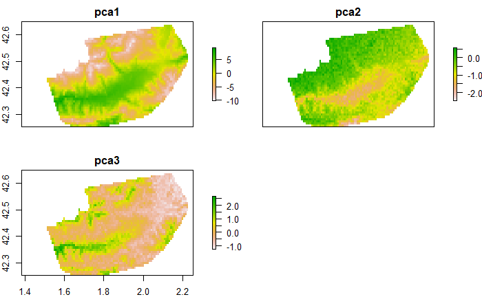

```r
plot(egv1)
```

## 1.1 Load environmental layers

```r
egv2<-stack(list.files(path=path2area2,pattern='asc',full.names=TRUE ))
# Descriptive statistics for environmental layers
summary(egv2)
```

```
                pca1         pca2          pca3
Min.     -10.5747786   -0.6012723   -1.01897073
1st Qu.   -2.5077504    0.3118767   -0.30940518
Median     0.5174904    0.6437626   -0.03810998
3rd Qu.    3.7238312    1.0317967    0.27661410
Max.       9.5737438    2.0112510    1.87297201
NA's    2061.0000000 2061.0000000 2061.00000000
```

# 2 Plot variables

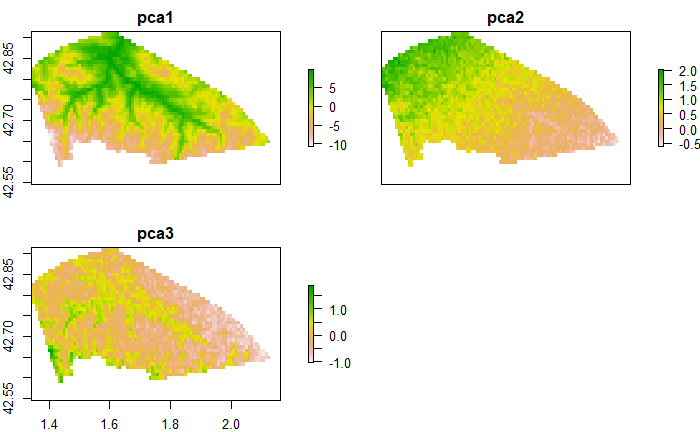

```r
plot(egv2)
```

# 3 Sample Environmental Variables

Ecospat does not work with rasters - for species 1

```r
clim1<-data.frame(rasterToPoints(egv1))
head(clim1)
```

|  | x | y | pca1 | pca2 | pca3 |
| --- | --- | --- | --- | --- | --- |
| 1 | 2.105783 | 42.63459 | 1.5312246 | -0.01880494 | -0.97698182 |
| 2 | 2.114116 | 42.63459 | 1.7078209 | -0.32138574 | -0.70462322 |
| 3 | 2.122449 | 42.63459 | 1.8448411 | -0.29904145 | -0.71304822 |
| 4 | 2.130783 | 42.63459 | 2.0360096 | -0.63112736 | -0.58516932 |
| 5 | 2.139116 | 42.63459 | 0.9618205 | -0.42914742 | -0.78587216 |
| 6 | 2.039116 | 42.62626 | -4.4867802 | -0.42281491 | 0.07932714 |

```r
View(clim1)
```

- for species 2

```r
clim2<-data.frame(rasterToPoints(egv2))
head(clim2)
```

|  | x | y | pca1 | pca2 | pca3 |
| --- | --- | --- | --- | --- | --- |
| 1 | 1.572449 | 42.90959 | 1.937481 | 1.453602 | -0.48178479 |
| 2 | 1.580783 | 42.90959 | 3.008670 | 1.352878 | -0.13824297 |
| 3 | 1.589116 | 42.90959 | 3.741471 | 1.340294 | -0.19024460 |
| 4 | 1.597449 | 42.90959 | 4.503046 | 1.290364 | 0.09718762 |
| 5 | 1.605783 | 42.90959 | 5.091908 | 1.457495 | 0.32152781 |
| 6 | 1.614116 | 42.90959 | 5.626893 | 1.350985 | 0.10593234 |

```r
#View(clim2)
```

- global climate for both ranges

combine them

```r
clim12<-rbind(clim1,clim2)
head(clim12)
```

|  | x | y | pca1 | pca2 | pca3 |
| --- | --- | --- | --- | --- | --- |
| 1 | 2.105783 | 42.63459 | 1.5312246 | -0.01880494 | -0.97698182 |
| 2 | 2.114116 | 42.63459 | 1.7078209 | -0.32138574 | -0.70462322 |
| 3 | 2.122449 | 42.63459 | 1.8448411 | -0.29904145 | -0.71304822 |
| 4 | 2.130783 | 42.63459 | 2.0360096 | -0.63112736 | -0.58516932 |
| 5 | 2.139116 | 42.63459 | 0.9618205 | -0.42914742 | -0.78587216 |
| 6 | 2.039116 | 42.62626 | -4.4867802 | -0.42281491 | 0.07932714 |

## 3.1 loading occurrence sites for the species (column names should be x,y)

- species 1

```r
occ.sp1<-na.exclude(read.delim(path2sp1,h=T,sep=","))
```

export in qgic save as chose comma separated file or load directly shape file

check species 1

```r
head(occ.sp1)
```

|  | species | x | y | occ |
| --- | --- | --- | --- | --- |
| 1 | species1 | 1.857741 | 42.57740 | 1 |
| 2 | species1 | 2.157835 | 42.43353 | 1 |
| 3 | species1 | 1.957816 | 42.57533 | 1 |
| 4 | species1 | 1.940463 | 42.58591 | 1 |
| 5 | species1 | 1.766440 | 42.48247 | 1 |
| 6 | species1 | 1.784693 | 42.48928 | 1 |

```r
str(occ.sp1)
```

```
'data.frame':   32 obs. of  4 variables:
 $ species: Factor w/ 1 level "species1": 1 1 1 1 1 1 1 1 1 1 ...
 $ x      : num  1.86 2.16 1.96 1.94 1.77 ...
 $ y      : num  42.6 42.4 42.6 42.6 42.5 ...
 $ occ    : int  1 1 1 1 1 1 1 1 1 1 ...
```

OCC is species ID - must be numerical

Plot species 1

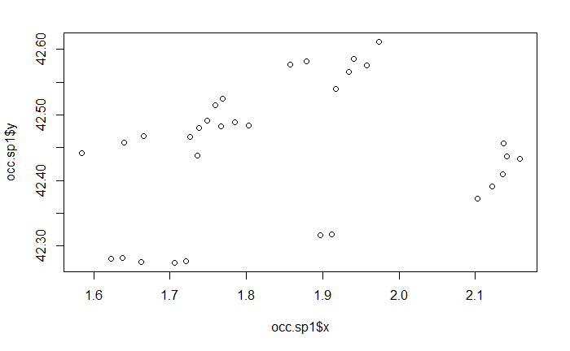

```r
plot(occ.sp1$x,occ.sp1$y)
```

# 4 species 2

```r
occ.sp2<-na.exclude(read.delim(path2sp2,h=T,sep=","))
# check species 2
head(occ.sp2)
```

|  | species | x | y | occ |
| --- | --- | --- | --- | --- |
| 1 | species2 | 1.836248 | 42.71155 | 1 |
| 2 | species2 | 1.829334 | 42.69900 | 1 |
| 3 | species2 | 1.833634 | 42.70694 | 1 |
| 4 | species2 | 1.597378 | 42.87132 | 1 |
| 5 | species2 | 1.859247 | 42.72210 | 1 |
| 6 | species2 | 1.674600 | 42.77446 | 1 |

```r
str(occ.sp2)
```

```
'data.frame':   32 obs. of  4 variables:
 $ species: Factor w/ 1 level "species2": 1 1 1 1 1 1 1 1 1 1 ...
 $ x      : num  1.84 1.83 1.83 1.6 1.86 ...
 $ y      : num  42.7 42.7 42.7 42.9 42.7 ...
 $ occ    : int  1 1 1 1 1 1 1 1 1 1 ...
```